Author

[Carlos González](https://gonzalezgarcia.github.io/)

# Welcome

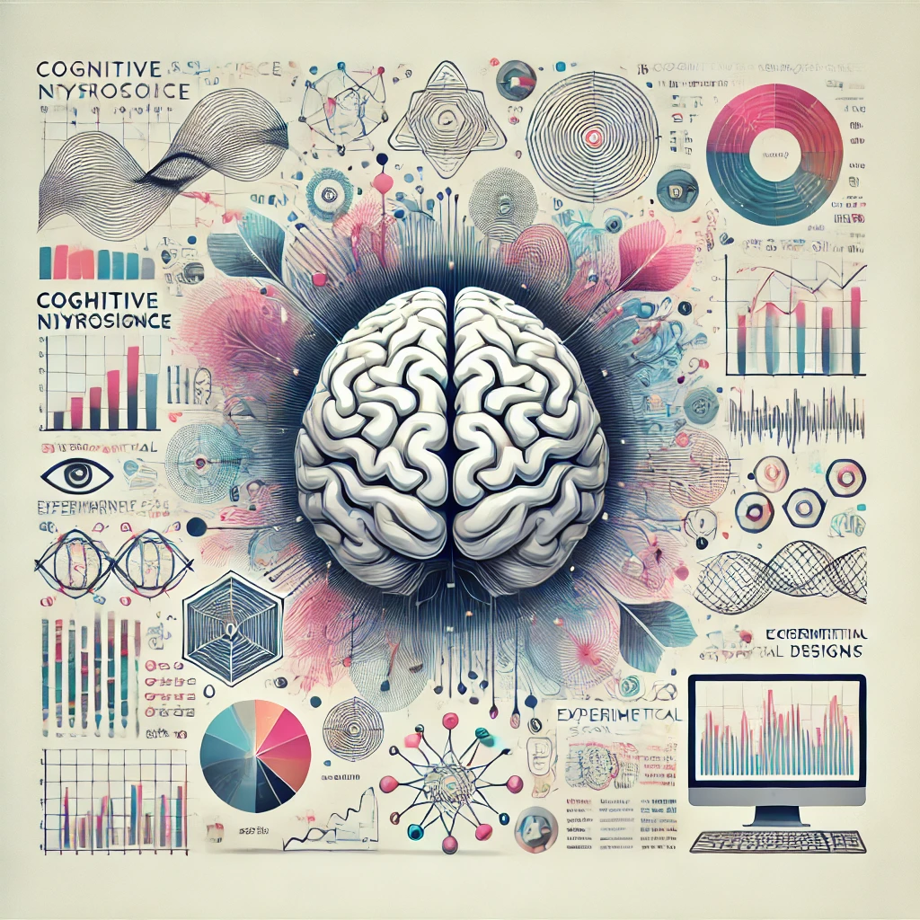

AI algorithm hallucinates what this course is about

This text is aimed to serve as your guide for the first half of the course “Methodology in Cognitive Neuroscience: Basic and Applied Research” in the Master’s Program in Cognitive and Behavioral Neuroscience at the University of Granada.

In this section, we will explore the foundations of experimental research in cognitive neuroscience and develop practical skills in experiment programming. We’ll begin by introducing key concepts in research methods and experimental thinking, providing you with a solid theoretical foundation. Then, we’ll dive into hands-on training using [**E-Prime**](https://pstnet.com/products/e-prime/) and [**OpenSesame**](https://osdoc.cogsci.nl/), two powerful pieces of software for creating psychology experiments.

By the end of this module, you will be able to:

- Understand and apply principles of experimental design in cognitive neuroscience
- Think critically about research methodology and experimental control
- Design and program your own experiments using E-Prime and OpenSesame
- Troubleshoot common issues in experiment programming

This guide is designed to be both theoretical and practical. Most of the chapters include conceptual discussions followed by hands-on exercises to help you apply what you’ve learned. Remember, mastering these skills requires practice, creativity, and persistence!

**Relevant links**

[Course guide](https://masteres.ugr.es/neurocg/docencia/plan-estudios/guia-docente/M30/56/2/27)

**Disclaimer**

This material has been elaborated for the use of the Cognitive Neuroscience master students of the Universidad de Granada, years 2023-25.

The resources listed here are Open Educational Resources (OER) that are free to use, share, copy, and edit, with attribution, following the terms of the specified license.

Please contact [Carlos González](https://ugr.es/~cgonzalez) for any inquiry.